# Introduction to data science

Experiential Data science for Undergraduate Cross-disciplinary Education

Dr. Kim Dill-McFarland, U. of British Columbia

# Introduction to data science

## Learning objectives

- Define data science
- List common tools used in data science

## What is ‘data science’?

[figure not shown]

[Wikipedia](https://en.wikipedia.org/wiki/Data_science) defines ‘data science’ as

- “an *interdisciplinary* field that uses scientific methods, processes, algorithms, and systems to extract knowledge and insights from *data* in various forms”
- “a concept to unify *statistics, data analysis, machine learning and their related methods* in order to understand and analyze actual phenomena with data.”

So, data science comprises many types of **data** and whatever **tools** you need to **extract meaning** from that data. The process is both cyclic and iterative, similar to the scientific method. The skills you learn here are applicable to a wide range of disciplines and data types. Thus, data science can serve as the foundational to many current and future careers.

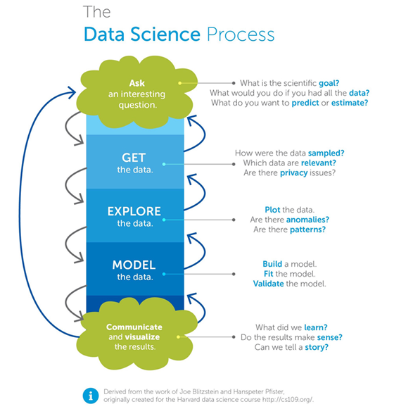

## Fundamental tools in data science

Common tools in data science that are:

- command line (*e.g.* Unix) to remotely access computational resources
- scripting languages (*e.g.* R, python, MATLAB) to manipulation and plot data
- statistics to extract significant results

To learn more about these tools and their applications, please continue to explore the [EDUCE](https://educe-ubc.github.io/) curriculum such as the module(s) contained here. There are also many other tools like deep learning, machine learning, and discipline-specific command line programs that are not covered here! So, be sure to explore more with online courses on platforms like:

- [The Carpentries](https://carpentries.org/)
- [edX](https://www.edx.org/)
- [Codecademy](https://www.codecademy.com/)
- [swirl](https://swirlstats.com/)
- [Udemy](https://www.udemy.com/)